**5420 ANOMALY DETECTION**

**A5:** EDA Best Practices

Zeying Liu (zl3121)5420 ANOMALY DETECTION

# 0. Content

> Content

> Data Preparation

> Initial observations

> Feature Engineering

> > ratio(mean(Agency_Merchant))

> > ratio(median(Agency_Merchant))

> > ratio(mean(Agency_Merchant_Month))

> > ratio(median(Agency_Marchant_Month))

> > ratio(mean(Agency_Marchant_Year))

> > ratio(median(Agency_Marchant_Year))

> > ratio(mean(Agency_Marchant_Week))

> > ratio(median(Agency_Marchant_Week))

> > ratio(mean(Agency_Marchant_Day))

> > ratio(median(Agency_Marchant_Day))

> > ratio(median(person_Marchant_Month))

> > ratio(median(person_Marchant_Year))

> > ratio(mean(person_Marchant_Month))

> > Days_since_last(Agency_Vendor)

> > Days_since_last(Agency_Marchant)

> merge

> Modeling

> > 5.1 Apply KNN

> > 5.2 Cluster

> Aggregating Models

> > 6.1 Average

> > 6.2 The Maximum of Maximum (MOM)

> > 6.3: The Average of Maximum (AOM)

> > 6.4 The maximum of average (MOA)

# 1. Data Preparation

```python
import pandas as pd
```

```python
# Read data
df = pd.read_csv('purchase_credit_card.csv')
```

```python
# Check Null value
df.isnull().values.sum()
```

```
0
```

```python
# change column names
df.columns = ['Year_Month', 'Agency_Number', 'Agency_Name', 'Cardholder_Last_Name',
      'Cardholder_First_Initial', 'Description', 'Amount', 'Vendor', 'Transaction_Date',
      'Posted_Date', 'Merchant_Category']
```

```python
# Data Overview
df.describe()
```

|  | Year_Month | Agency_Number | Amount |
| --- | --- | --- | --- |
| count | 442458.000000 | 442458.000000 | 4.424580e+05 |
| mean | 201357.284375 | 42785.860353 | 4.249912e+02 |
| std | 47.107417 | 33378.461293 | 5.266509e+03 |
| min | 201307.000000 | 1000.000000 | -4.286304e+04 |
| 25% | 201309.000000 | 1000.000000 | 3.091000e+01 |
| 50% | 201401.000000 | 47700.000000 | 1.048900e+02 |
| 75% | 201404.000000 | 76000.000000 | 3.450000e+02 |
| max | 201406.000000 | 98000.000000 | 1.903858e+06 |

```python
# Convert data format
df['Transaction_Date']=pd.to_datetime(df['Transaction_Date'])
df['Posted_Date']=pd.to_datetime(df['Posted_Date'])
df['Year_Month'].dtype
df['Year_Month']=pd.to_datetime(df['Year_Month'], format='%Y%m')
df['Year'] = df['Year_Month'].dt.year
df['Month'] = df['Year_Month'].dt.month

# Create 'Week'column
df['Week_Number'] = df['Transaction_Date'].dt.isocalendar().week

# Creating 'Day_of_Week' from 'Transaction_Date'
dayOfWeek={0:'Monday', 1:'Tuesday', 2:'Wednesday', 3:'Thursday', 4:'Friday', 5:'Saturday', 6:'Sunday'}
df['Day_of_Week'] = df['Transaction_Date'].dt.dayofweek.map(dayOfWeek)

df['Day_of_Week'].value_counts()
```

```
Wednesday    89644
Thursday     87537
Tuesday      86919
Friday       79917
Monday       61809
Saturday     26307
Sunday       10325
Name: Day_of_Week, dtype: int64
```

Interpretation:

Transactions were mainly on weekdays, with the highest number of transactions on Wednesday.

```python
df.head(5)
```

|  | Year_Month | Agency_Number | Agency_Name | Cardholder_Last_Name | Cardholder_First_Initial | Description | Amount | Vendor | Transaction_Date | Posted_Date | Merchant_Category | Year | Month | Week_Number | Day_of_Week |
| --- | --- | --- | --- | --- | --- | --- | --- | --- | --- | --- | --- | --- | --- | --- | --- |
| 0 | 2013-07-01 | 1000 | OKLAHOMA STATE UNIVERSITY | Mason | C | GENERAL PURCHASE | 890.00 | NACAS | 2013-07-30 | 2013-07-31 | CHARITABLE AND SOCIAL SERVICE ORGANIZATIONS | 2013 | 7 | 31 | Tuesday |
| 1 | 2013-07-01 | 1000 | OKLAHOMA STATE UNIVERSITY | Mason | C | ROOM CHARGES | 368.96 | SHERATON HOTEL | 2013-07-30 | 2013-07-31 | SHERATON | 2013 | 7 | 31 | Tuesday |
| 2 | 2013-07-01 | 1000 | OKLAHOMA STATE UNIVERSITY | Massey | J | GENERAL PURCHASE | 165.82 | SEARS.COM 9300 | 2013-07-29 | 2013-07-31 | DIRCT MARKETING/DIRCT MARKETERS--NOT ELSEWHERE... | 2013 | 7 | 31 | Monday |
| 3 | 2013-07-01 | 1000 | OKLAHOMA STATE UNIVERSITY | Massey | T | GENERAL PURCHASE | 96.39 | WAL-MART #0137 | 2013-07-30 | 2013-07-31 | GROCERY STORES,AND SUPERMARKETS | 2013 | 7 | 31 | Tuesday |
| 4 | 2013-07-01 | 1000 | OKLAHOMA STATE UNIVERSITY | Mauro-Herrera | M | HAMMERMILL COPY PLUS COPY EA | 125.96 | STAPLES DIRECT | 2013-07-30 | 2013-07-31 | STATIONERY, OFFICE SUPPLIES, PRINTING AND WRIT... | 2013 | 7 | 31 | Tuesday |

# 2. Initial observations

```python
import numpy as np
import plotly
import plotly.express as px
import seaborn as sns
```

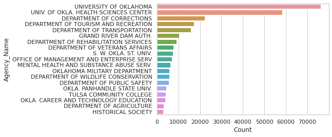

```python
# Count trans by agency_name
df_count = df['Agency_Name'].value_counts()
df_count = pd.DataFrame(df_count).reset_index()
df_count.columns = ['Agency_Name','Count']

fig = px.bar(df_count, x='Agency_Name', y='Count', color = 'Agency_Name', width=1000, height=400)

sns.set_theme(style="whitegrid")
sns.barplot(y="Agency_Name", x="Count", data=df_count[1:20])
```

**`Interpretation:`**

The number of purchases varies greatly from agency to agency, so it is essential to aggregate by agency when comparing amount of spendings.

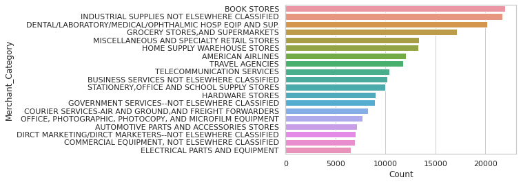

```python
df_cate = df['Merchant_Category'].value_counts()
df_cate = pd.DataFrame(df_cate).reset_index()
df_cate.columns = ['Merchant_Category','Count']

fig = px.bar(df_cate, x='Merchant_Category', y='Count', color = 'Merchant_Category', width=1000, height=400)

sns.set_theme(style="whitegrid")
sns.barplot(y="Merchant_Category", x="Count", data=df_cate[1:20])
```

**`Interpretation:`**

It is also easy to see from the visualization result above that there is **a large difference in the number of purchases between merchant categories**. Therefore, when identifying outliers, merchant categories should be aggregated as well.

# 3. Feature Engineering

Before modeling, I modified my features. I kept the first 13 features which are based on the aggregation of agencies, vendors, merchants and individual users and calculated the benchmark by calculating the average or median spending amount, and finally compared the actual spending amount of each user with the benchmark and selected the largest 10% as outliers.

Then, I removed the features that originally measured the number of transactions by count and added two features measured from the recency perspective. They are intended to measure the time interval between each user's last two purchases under the same vendor or merchant. It also screens out those with too large an interval to measure as potential abnormal consumption.

The dataset recorded the companies(agency_name) of the cardholders, the location of the transactions, the date of making a purchase, as well as the category of the marchant.

From my point of view, they are all good measures of anomalies. In the following section, I would like to use the standard transaction records by combining the above variables and using the average/total/count/ratio/median. Then select the appropriate benchmark based on the distribution of the data to eventually identify credit card fraud.

## 1. ratio(mean(Agency_Merchant))

A company's location, salary and culture should have an impact on an employee's purchase choices. By calculating the average amount per organization in each category, it helps me to identify some abuses of credit cards.

```python
stat_by_agency = df.groupby(['Agency_Name', 'Merchant_Category'])['Amount'].mean()
stat_by_agency = pd.DataFrame(stat_by_agency)
stat_by_agency.columns = ['AVG_amount']
stat_by_agency
```

| Agency_Name | Merchant_Category | AVG_amount |
| --- | --- | --- |
| ARDMORE HIGHER EDUCATION CENTER | BUSINESS SERVICES NOT ELSEWHERE CLASSIFIED | 115.120000 |
|  | CATALOG MERCHANTS | -53.344286 |
|  | COMPUTER NETWORK/INFORMATION SERVICES | 18.340000 |
|  | DRUG STORES AND PHARMACIES | 153.450000 |
|  | GROCERY STORES,AND SUPERMARKETS | 74.525455 |
| ... | ... | ... |
| `DEPARTMENT OF EDUCATION | TELECOMMUNICATION SERVICES | 118.054000 |
|  | TRAVEL AGENCIES | 24.253731 |
|  | TROPICANA RESORT AND CASINO | 481.600000 |
|  | UNITED AIRLINES | 310.547368 |
|  | WYNDHAM HOTELS | 93.282857 |

8427 rows × 1 columns

```python
# add the new feature to the dataset
df1 = pd.merge(df, stat_by_agency, how='left', on=['Agency_Name', 'Merchant_Category'])
# Feature 1: ratio of amount spending and avergae spending by merchant category
df1['agency_merchant_avg_ratio_amount'] = np.where(df1['AVG_amount']==0,0, df1['Amount'] / df1['AVG_amount'])
df1['agency_merchant_avg_ratio_amount'].describe()
```

```
count    442458.000000
mean          0.999724
std           7.225363
min       -2735.680000
25%           0.177145
50%           0.515301
75%           1.102916
max        2735.680000
Name: agency_merchant_avg_ratio_amount, dtype: float64
```

```
[Text(0, 0, '(-2735.681, -0.681]'),
```

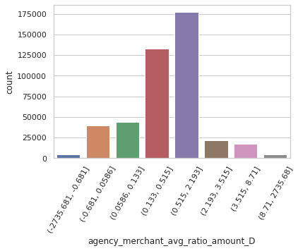

```python
# cut by percentile for plotting
var = 'agency_merchant_avg_ratio_amount'
binned_var = var + '_D'
percentile = [0,0.01,0.1,0.2,0.5,0.9,0.95,0.99,1]
df1[binned_var] = pd.qcut(df1[var],percentile)

# Visualization
g = sns.countplot(x="agency_merchant_avg_ratio_amount_D", data=df1)
g.set_xticklabels(g.get_xticklabels(), rotation = 60)
```

Assuming that the top **10%** of the **agency_merchant_avg_ratio_amount** are credit card fraud (credit card abuse), choose 2 as the benchmark to filter out the following transactions.

```python
df1[df1['agency_merchant_avg_ratio_amount']>2].head()
```

|  | Year_Month | Agency_Number | Agency_Name | Cardholder_Last_Name | Cardholder_First_Initial | Description | Amount | Vendor | Transaction_Date | Posted_Date | Merchant_Category | Year | Month | Week_Number | Day_of_Week | AVG_amount | agency_merchant_avg_ratio_amount | agency_merchant_avg_ratio_amount_D |
| --- | --- | --- | --- | --- | --- | --- | --- | --- | --- | --- | --- | --- | --- | --- | --- | --- | --- | --- |
| 0 | 2013-07-01 | 1000 | OKLAHOMA STATE UNIVERSITY | Mason | C | GENERAL PURCHASE | 890.00 | NACAS | 2013-07-30 | 2013-07-31 | CHARITABLE AND SOCIAL SERVICE ORGANIZATIONS | 2013 | 7 | 31 | Tuesday | 427.634060 | 2.081219 | (0.515, 2.193] |
| 16 | 2013-07-01 | 1000 | OKLAHOMA STATE UNIVERSITY | Mohiuddin | I | GENERAL PURCHASE | 2425.00 | WESTERN EQUIPMENT ALVA | 2013-07-29 | 2013-07-31 | HARDWARE STORES | 2013 | 7 | 31 | Monday | 170.060436 | 14.259636 | (8.71, 2735.68] |
| 17 | 2013-07-01 | 1000 | OKLAHOMA STATE UNIVERSITY | Mohiuddin | I | GENERAL PURCHASE | 2425.00 | WESTERN EQUIPMENT ALVA | 2013-07-29 | 2013-07-31 | HARDWARE STORES | 2013 | 7 | 31 | Monday | 170.060436 | 14.259636 | (8.71, 2735.68] |
| 33 | 2013-07-01 | 1000 | OKLAHOMA STATE UNIVERSITY | Gerlt | T | GENERAL PURCHASE | 3582.00 | TELVENT | 2013-07-26 | 2013-07-29 | BUSINESS SERVICES NOT ELSEWHERE CLASSIFIED | 2013 | 7 | 30 | Friday | 392.641168 | 9.122833 | (8.71, 2735.68] |
| 35 | 2013-07-01 | 1000 | OKLAHOMA STATE UNIVERSITY | GODSEY | R | GENERAL PURCHASE | 407.85 | OPTIMUM ENERGY PROD | 2013-07-26 | 2013-07-29 | HARDWARE STORES | 2013 | 7 | 30 | Friday | 170.060436 | 2.398265 | (2.193, 3.515] |

## 2. ratio(median(Agency_Merchant))

The mean may have some limitations, for example, when there is already a large amount of credit card fraud in the record, it may lead to the mean being significantly increased, resulting in some false positives. Therefore, the median is added as a supplementary consideration.

```python
stat_by_agency = df.groupby(['Agency_Name', 'Merchant_Category'])['Amount'].median()
stat_by_agency = pd.DataFrame(stat_by_agency)
stat_by_agency.columns = ['Median_amount']

#add the new feature to the dataset
df2 = pd.merge(df, stat_by_agency, how='left', on=['Agency_Name', 'Merchant_Category'])

# Feature 2:
df2['agency_merchant_median_ratio_amount'] = np.where(df2['Median_amount']==0,0, df2['Amount'] / df2['Median_amount'])
df2['agency_merchant_median_ratio_amount'].describe()
```

```
count    442458.000000
mean          4.952685
std        1078.581350
min       -1003.176471
25%           0.466090
50%           1.000000
75%           2.121102
max      528116.052705
Name: agency_merchant_median_ratio_amount, dtype: float64
```

```
[Text(0, 0, '(-1003.177, -1.121]'),
```

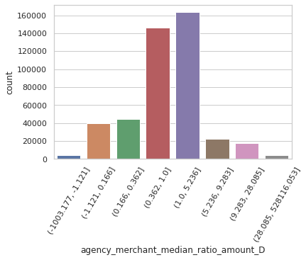

```python
var = 'agency_merchant_median_ratio_amount'
binned_var = var + '_D'
percentile = [0,0.01,0.1,0.2,0.5,0.9,0.95,0.99,1]
df2[binned_var] = pd.qcut( df2[var],percentile)
g = sns.countplot(x="agency_merchant_median_ratio_amount_D", data=df2)
g.set_xticklabels(g.get_xticklabels(), rotation = 60)
```

Assuming that the top 10% of the agency_merchant_median_ratio_amount are credit card fraud (credit card abuse), choose 5 as the BENCHMARK to filter out the following transactions.

```python
df2[df2['agency_merchant_median_ratio_amount']>5].head()
```

|  | Year_Month | Agency_Number | Agency_Name | Cardholder_Last_Name | Cardholder_First_Initial | Description | Amount | Vendor | Transaction_Date | Posted_Date | Merchant_Category | Year | Month | Week_Number | Day_of_Week | Median_amount | agency_merchant_median_ratio_amount | agency_merchant_median_ratio_amount_D |
| --- | --- | --- | --- | --- | --- | --- | --- | --- | --- | --- | --- | --- | --- | --- | --- | --- | --- | --- |
| 16 | 2013-07-01 | 1000 | OKLAHOMA STATE UNIVERSITY | Mohiuddin | I | GENERAL PURCHASE | 2425.00 | WESTERN EQUIPMENT ALVA | 2013-07-29 | 2013-07-31 | HARDWARE STORES | 2013 | 7 | 31 | Monday | 54.835 | 44.223580 | (28.085, 528116.053] |
| 17 | 2013-07-01 | 1000 | OKLAHOMA STATE UNIVERSITY | Mohiuddin | I | GENERAL PURCHASE | 2425.00 | WESTERN EQUIPMENT ALVA | 2013-07-29 | 2013-07-31 | HARDWARE STORES | 2013 | 7 | 31 | Monday | 54.835 | 44.223580 | (28.085, 528116.053] |
| 33 | 2013-07-01 | 1000 | OKLAHOMA STATE UNIVERSITY | Gerlt | T | GENERAL PURCHASE | 3582.00 | TELVENT | 2013-07-26 | 2013-07-29 | BUSINESS SERVICES NOT ELSEWHERE CLASSIFIED | 2013 | 7 | 30 | Friday | 154.000 | 23.259740 | (9.283, 28.085] |
| 35 | 2013-07-01 | 1000 | OKLAHOMA STATE UNIVERSITY | GODSEY | R | GENERAL PURCHASE | 407.85 | OPTIMUM ENERGY PROD | 2013-07-26 | 2013-07-29 | HARDWARE STORES | 2013 | 7 | 30 | Friday | 54.835 | 7.437768 | (5.236, 9.283] |
| 47 | 2013-07-01 | 1000 | OKLAHOMA STATE UNIVERSITY | DALCOUR | K | GENERAL PURCHASE | 1312.20 | NATURAL WATER COMPANY LLC | 2013-07-24 | 2013-07-26 | BUSINESS SERVICES NOT ELSEWHERE CLASSIFIED | 2013 | 7 | 30 | Wednesday | 154.000 | 8.520779 | (5.236, 9.283] |

## 3. ratio(mean(Agency_Merchant_Month))

There is a pattern to the amount of money people spend on groceries, which is the bulk of their living expenses. First, let's start the test with a month.

```python
stat_by_agency = df.groupby(['Agency_Name', 'Merchant_Category','Month'])['Amount'].mean()
stat_by_agency = pd.DataFrame(stat_by_agency)
stat_by_agency.columns = ['AVG_amount']

#add the new feature to the dataset
df3 = pd.merge(df, stat_by_agency, how='left', on=['Agency_Name', 'Merchant_Category','Month'])

# Feature 3:
df3['agency_merchant_month_avg_ratio_amount'] = np.where(df3['AVG_amount']==0,0, df3['Amount'] / df3['AVG_amount'])
df3['agency_merchant_month_avg_ratio_amount'].describe()
```

```
count    4.424580e+05
mean     9.993083e-01
std      5.961952e+13
min     -2.447706e+16
25%      2.017647e-01
50%      5.984763e-01
75%      1.125213e+00
max      3.059633e+16
Name: agency_merchant_month_avg_ratio_amount, dtype: float64
```

```
[Text(0, 0, '(-2.4477063974758644e+16, -0.734]'),
```

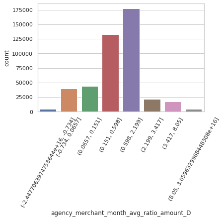

```python
# cut by percentile for plotting
var = 'agency_merchant_month_avg_ratio_amount'
binned_var = var + '_D'
percentile = [0,0.01,0.1,0.2,0.5,0.9,0.95,0.99,1]
df3[binned_var] = pd.qcut(df3[var],percentile)

# Visualization
g = sns.countplot(x="agency_merchant_month_avg_ratio_amount_D", data=df3)
g.set_xticklabels(g.get_xticklabels(), rotation = 60)
```

Assuming that the top 10% of the agency_merchant_month_avg_ratio_amount are credit card fraud (credit card abuse), choose 2 as the benchmark to filter out the following transactions.

```python
df3[df3['agency_merchant_month_avg_ratio_amount']>2].head()
```

|  | Year_Month | Agency_Number | Agency_Name | Cardholder_Last_Name | Cardholder_First_Initial | Description | Amount | Vendor | Transaction_Date | Posted_Date | Merchant_Category | Year | Month | Week_Number | Day_of_Week | AVG_amount | agency_merchant_month_avg_ratio_amount | agency_merchant_month_avg_ratio_amount_D |
| --- | --- | --- | --- | --- | --- | --- | --- | --- | --- | --- | --- | --- | --- | --- | --- | --- | --- | --- |
| 16 | 2013-07-01 | 1000 | OKLAHOMA STATE UNIVERSITY | Mohiuddin | I | GENERAL PURCHASE | 2425.0 | WESTERN EQUIPMENT ALVA | 2013-07-29 | 2013-07-31 | HARDWARE STORES | 2013 | 7 | 31 | Monday | 235.679053 | 10.289417 | (8.05, 3.0596329968448308e+16] |
| 17 | 2013-07-01 | 1000 | OKLAHOMA STATE UNIVERSITY | Mohiuddin | I | GENERAL PURCHASE | 2425.0 | WESTERN EQUIPMENT ALVA | 2013-07-29 | 2013-07-31 | HARDWARE STORES | 2013 | 7 | 31 | Monday | 235.679053 | 10.289417 | (8.05, 3.0596329968448308e+16] |
| 33 | 2013-07-01 | 1000 | OKLAHOMA STATE UNIVERSITY | Gerlt | T | GENERAL PURCHASE | 3582.0 | TELVENT | 2013-07-26 | 2013-07-29 | BUSINESS SERVICES NOT ELSEWHERE CLASSIFIED | 2013 | 7 | 30 | Friday | 568.982548 | 6.295448 | (3.417, 8.05] |
| 47 | 2013-07-01 | 1000 | OKLAHOMA STATE UNIVERSITY | DALCOUR | K | GENERAL PURCHASE | 1312.2 | NATURAL WATER COMPANY LLC | 2013-07-24 | 2013-07-26 | BUSINESS SERVICES NOT ELSEWHERE CLASSIFIED | 2013 | 7 | 30 | Wednesday | 568.982548 | 2.306222 | (2.199, 3.417] |
| 49 | 2013-07-01 | 1000 | OKLAHOMA STATE UNIVERSITY | DALCOUR | K | GENERAL PURCHASE | 914.0 | AUTO-CHLOR SERVICES INC | 2013-07-24 | 2013-07-26 | CATALOG MERCHANTS | 2013 | 7 | 30 | Wednesday | 450.829655 | 2.027373 | (0.598, 2.199] |

## 4. ratio(median(Agency_Marchant_Month))

Similarly, the median is again used to complement the mean.

```python
stat_by_agency = df.groupby(['Agency_Name', 'Merchant_Category','Month'])['Amount'].median()
stat_by_agency = pd.DataFrame(stat_by_agency)
stat_by_agency.columns = ['Median_amount']

#add the new feature to the dataset
df4 = pd.merge(df, stat_by_agency, how='left', on=['Agency_Name', 'Merchant_Category','Month'])

# Feature 4:
df4['agency_merchant_month_median_ratio_amount'] = np.where(df4['Median_amount']==0,0, df4['Amount'] / df4['Median_amount'])
df4['agency_merchant_month_median_ratio_amount'].describe()
```

```
count    442458.000000
mean          5.010047
std        1195.766096
min      -29642.000000
25%           0.500000
50%           1.000000
75%           1.912717
max      598420.505983
Name: agency_merchant_month_median_ratio_amount, dtype: float64
```

```
[Text(0, 0, '(-29642.001, -1.103]'),
```

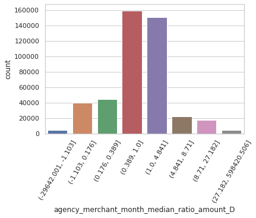

```python
var = 'agency_merchant_month_median_ratio_amount'
binned_var = var + '_D'
percentile = [0,0.01,0.1,0.2,0.5,0.9,0.95,0.99,1]
df4[binned_var] = pd.qcut( df4[var],percentile)
g = sns.countplot(x="agency_merchant_month_median_ratio_amount_D", data=df4)
g.set_xticklabels(g.get_xticklabels(), rotation = 60)
```

Assuming that the top 10% of the agency_merchant_month_median_ratio_amount are credit card fraud (credit card abuse), choose 4(round down to reduce the probability of false positive) as the BENCHMARK to filter out the following transactions.

```python
df4[df4['agency_merchant_month_median_ratio_amount']>4].head()
```

|  | Year_Month | Agency_Number | Agency_Name | Cardholder_Last_Name | Cardholder_First_Initial | Description | Amount | Vendor | Transaction_Date | Posted_Date | Merchant_Category | Year | Month | Week_Number | Day_of_Week | Median_amount | agency_merchant_month_median_ratio_amount | agency_merchant_month_median_ratio_amount_D |
| --- | --- | --- | --- | --- | --- | --- | --- | --- | --- | --- | --- | --- | --- | --- | --- | --- | --- | --- |
| 14 | 2013-07-01 | 1000 | OKLAHOMA STATE UNIVERSITY | Meints | K | GENERAL PURCHASE | 445.00 | OK DEPT OF VO-TECH ED | 2013-07-30 | 2013-07-31 | GOVERNMENT SERVICES--NOT ELSEWHERE CLASSIFIED | 2013 | 7 | 31 | Tuesday | 65.000 | 6.846154 | (4.841, 8.71] |
| 16 | 2013-07-01 | 1000 | OKLAHOMA STATE UNIVERSITY | Mohiuddin | I | GENERAL PURCHASE | 2425.00 | WESTERN EQUIPMENT ALVA | 2013-07-29 | 2013-07-31 | HARDWARE STORES | 2013 | 7 | 31 | Monday | 60.535 | 40.059470 | (27.182, 598420.506] |
| 17 | 2013-07-01 | 1000 | OKLAHOMA STATE UNIVERSITY | Mohiuddin | I | GENERAL PURCHASE | 2425.00 | WESTERN EQUIPMENT ALVA | 2013-07-29 | 2013-07-31 | HARDWARE STORES | 2013 | 7 | 31 | Monday | 60.535 | 40.059470 | (27.182, 598420.506] |
| 33 | 2013-07-01 | 1000 | OKLAHOMA STATE UNIVERSITY | Gerlt | T | GENERAL PURCHASE | 3582.00 | TELVENT | 2013-07-26 | 2013-07-29 | BUSINESS SERVICES NOT ELSEWHERE CLASSIFIED | 2013 | 7 | 30 | Friday | 198.500 | 18.045340 | (8.71, 27.182] |
| 35 | 2013-07-01 | 1000 | OKLAHOMA STATE UNIVERSITY | GODSEY | R | GENERAL PURCHASE | 407.85 | OPTIMUM ENERGY PROD | 2013-07-26 | 2013-07-29 | HARDWARE STORES | 2013 | 7 | 30 | Friday | 60.535 | 6.737425 | (4.841, 8.71] |

## 5. ratio(mean(Agency_Marchant_Year))

Through the in-depth knowledge of time series in the previous lesson, it was found that people's consumption habits are also influenced by weather and holidays during the year. Therefore, the average is then calculated in terms of years, and don't identify possible credit card fraud.

```python
stat_by_agency = df.groupby(['Agency_Name', 'Merchant_Category','Year'])['Amount'].mean()
stat_by_agency = pd.DataFrame(stat_by_agency)
stat_by_agency.columns = ['AVG_amount']

#add the new feature to the dataset
df5 = pd.merge(df, stat_by_agency, how='left', on=['Agency_Name', 'Merchant_Category','Year'])

# Feature 5:
df5['agency_merchant_year_avg_ratio_amount'] = np.where(df5['AVG_amount']==0,0, df5['Amount'] / df5['AVG_amount'])
df5['agency_merchant_year_avg_ratio_amount'].describe()
```

```
count    4.424580e+05
mean     9.992721e-01
std      6.326476e+14
min     -1.733492e+17
25%      1.809953e-01
50%      5.296021e-01
75%      1.100599e+00
max      1.733492e+17
Name: agency_merchant_year_avg_ratio_amount, dtype: float64
```

```
[Text(0, 0, '(-1.733491791570246e+17, -0.68]'),
```

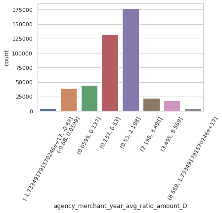

```python
# cut by percentile for plotting
var = 'agency_merchant_year_avg_ratio_amount'
binned_var = var + '_D'
percentile = [0,0.01,0.1,0.2,0.5,0.9,0.95,0.99,1]
df5[binned_var] = pd.qcut(df5[var],percentile)

# Visualization
g = sns.countplot(x="agency_merchant_year_avg_ratio_amount_D", data=df5)
g.set_xticklabels(g.get_xticklabels(), rotation = 60)
```

Assuming that the top 10% of the agency_merchant_year_avg_ratio_amount_D are credit card fraud (credit card abuse), choose 2 as the benchmark to filter out the following transactions.

```python
df5[df5['agency_merchant_year_avg_ratio_amount']>2].head()
```

|  | Year_Month | Agency_Number | Agency_Name | Cardholder_Last_Name | Cardholder_First_Initial | Description | Amount | Vendor | Transaction_Date | Posted_Date | Merchant_Category | Year | Month | Week_Number | Day_of_Week | AVG_amount | agency_merchant_year_avg_ratio_amount | agency_merchant_year_avg_ratio_amount_D |
| --- | --- | --- | --- | --- | --- | --- | --- | --- | --- | --- | --- | --- | --- | --- | --- | --- | --- | --- |
| 0 | 2013-07-01 | 1000 | OKLAHOMA STATE UNIVERSITY | Mason | C | GENERAL PURCHASE | 890.00 | NACAS | 2013-07-30 | 2013-07-31 | CHARITABLE AND SOCIAL SERVICE ORGANIZATIONS | 2013 | 7 | 31 | Tuesday | 442.352462 | 2.011970 | (0.53, 2.198] |
| 16 | 2013-07-01 | 1000 | OKLAHOMA STATE UNIVERSITY | Mohiuddin | I | GENERAL PURCHASE | 2425.00 | WESTERN EQUIPMENT ALVA | 2013-07-29 | 2013-07-31 | HARDWARE STORES | 2013 | 7 | 31 | Monday | 174.546405 | 13.893154 | (8.569, 1.733491791570246e+17] |
| 17 | 2013-07-01 | 1000 | OKLAHOMA STATE UNIVERSITY | Mohiuddin | I | GENERAL PURCHASE | 2425.00 | WESTERN EQUIPMENT ALVA | 2013-07-29 | 2013-07-31 | HARDWARE STORES | 2013 | 7 | 31 | Monday | 174.546405 | 13.893154 | (8.569, 1.733491791570246e+17] |
| 33 | 2013-07-01 | 1000 | OKLAHOMA STATE UNIVERSITY | Gerlt | T | GENERAL PURCHASE | 3582.00 | TELVENT | 2013-07-26 | 2013-07-29 | BUSINESS SERVICES NOT ELSEWHERE CLASSIFIED | 2013 | 7 | 30 | Friday | 424.422218 | 8.439709 | (3.495, 8.569] |
| 35 | 2013-07-01 | 1000 | OKLAHOMA STATE UNIVERSITY | GODSEY | R | GENERAL PURCHASE | 407.85 | OPTIMUM ENERGY PROD | 2013-07-26 | 2013-07-29 | HARDWARE STORES | 2013 | 7 | 30 | Friday | 174.546405 | 2.336628 | (2.198, 3.495] |

## 6. ratio(median(Agency_Marchant_Year))

Similarly, the median is again used to complement the mean.

```python
stat_by_agency = df.groupby(['Agency_Name', 'Merchant_Category','Year'])['Amount'].median()
stat_by_agency = pd.DataFrame(stat_by_agency)
stat_by_agency.columns = ['Median_amount']

#add the new feature to the dataset
df6 = pd.merge(df, stat_by_agency, how='left', on=['Agency_Name', 'Merchant_Category','Year'])

# Feature 6:
df6['agency_merchant_year_median_ratio_amount'] = np.where(df6['Median_amount']==0,0, df6['Amount'] / df6['Median_amount'])
df6['agency_merchant_year_median_ratio_amount'].describe()
```

```
count    442458.000000
mean          4.622487
std        1103.668041
min     -102375.000000
25%           0.474809
50%           1.000000
75%           2.083380
max      533293.661064
Name: agency_merchant_year_median_ratio_amount, dtype: float64
```

```
[Text(0, 0, '(-102375.001, -1.116]'),
```

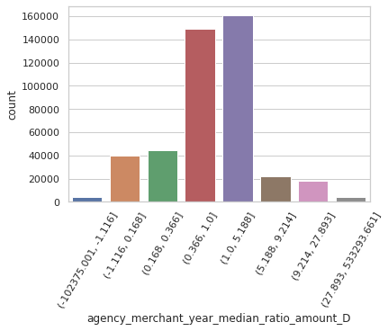

```python
var = 'agency_merchant_year_median_ratio_amount'
binned_var = var + '_D'
percentile = [0,0.01,0.1,0.2,0.5,0.9,0.95,0.99,1]
df6[binned_var] = pd.qcut( df6[var],percentile)
g = sns.countplot(x="agency_merchant_year_median_ratio_amount_D", data=df6)
g.set_xticklabels(g.get_xticklabels(), rotation = 60)
```

Assuming that the top 10% of the agency_merchant_year_median_ratio_amount_D are credit card fraud (credit card abuse), choose 5 as the BENCHMARK to filter out the following transactions.

```python
df6[df6['agency_merchant_year_median_ratio_amount']>5].head()
```

|  | Year_Month | Agency_Number | Agency_Name | Cardholder_Last_Name | Cardholder_First_Initial | Description | Amount | Vendor | Transaction_Date | Posted_Date | Merchant_Category | Year | Month | Week_Number | Day_of_Week | Median_amount | agency_merchant_year_median_ratio_amount | agency_merchant_year_median_ratio_amount_D |
| --- | --- | --- | --- | --- | --- | --- | --- | --- | --- | --- | --- | --- | --- | --- | --- | --- | --- | --- |
| 14 | 2013-07-01 | 1000 | OKLAHOMA STATE UNIVERSITY | Meints | K | GENERAL PURCHASE | 445.00 | OK DEPT OF VO-TECH ED | 2013-07-30 | 2013-07-31 | GOVERNMENT SERVICES--NOT ELSEWHERE CLASSIFIED | 2013 | 7 | 31 | Tuesday | 76.000 | 5.855263 | (5.188, 9.214] |
| 16 | 2013-07-01 | 1000 | OKLAHOMA STATE UNIVERSITY | Mohiuddin | I | GENERAL PURCHASE | 2425.00 | WESTERN EQUIPMENT ALVA | 2013-07-29 | 2013-07-31 | HARDWARE STORES | 2013 | 7 | 31 | Monday | 57.850 | 41.918755 | (27.893, 533293.661] |
| 17 | 2013-07-01 | 1000 | OKLAHOMA STATE UNIVERSITY | Mohiuddin | I | GENERAL PURCHASE | 2425.00 | WESTERN EQUIPMENT ALVA | 2013-07-29 | 2013-07-31 | HARDWARE STORES | 2013 | 7 | 31 | Monday | 57.850 | 41.918755 | (27.893, 533293.661] |
| 33 | 2013-07-01 | 1000 | OKLAHOMA STATE UNIVERSITY | Gerlt | T | GENERAL PURCHASE | 3582.00 | TELVENT | 2013-07-26 | 2013-07-29 | BUSINESS SERVICES NOT ELSEWHERE CLASSIFIED | 2013 | 7 | 30 | Friday | 169.965 | 21.074927 | (9.214, 27.893] |
| 35 | 2013-07-01 | 1000 | OKLAHOMA STATE UNIVERSITY | GODSEY | R | GENERAL PURCHASE | 407.85 | OPTIMUM ENERGY PROD | 2013-07-26 | 2013-07-29 | HARDWARE STORES | 2013 | 7 | 30 | Friday | 57.850 | 7.050130 | (5.188, 9.214] |

## 7. ratio(mean(Agency_Marchant_Week))

Now, let's take a week to start testing. We all know that credit card thieves will abuse credit card as much as possible in a short period of time before they are caught. Therefore, focusing on a week may be more effective than a year or a month.

```python
stat_by_agency = df.groupby(['Agency_Name', 'Merchant_Category','Week_Number'])['Amount'].mean()
stat_by_agency = pd.DataFrame(stat_by_agency)
stat_by_agency.columns = ['AVG_amount']

#add the new feature to the dataset
df7 = pd.merge(df, stat_by_agency, how='left', on=['Agency_Name', 'Merchant_Category','Week_Number'])

# Feature 7:
df7['agency_merchant_week_avg_ratio_amount'] = np.where(df7['AVG_amount']==0,0, df7['Amount'] / df7['AVG_amount'])
df7['agency_merchant_week_avg_ratio_amount'].describe()
```

```
count    4.424580e+05
mean     9.965862e-01
std      3.200676e+15
min     -6.078171e+17
25%      2.483801e-01
50%      7.446154e-01
75%      1.133222e+00
max      6.078171e+17
Name: agency_merchant_week_avg_ratio_amount, dtype: float64
```

```
[Text(0, 0, '(-6.078170647089906e+17, -0.847]'),
```

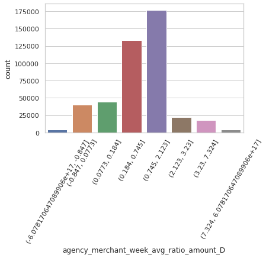

```python
# cut by percentile for plotting
var = 'agency_merchant_week_avg_ratio_amount'
binned_var = var + '_D'
percentile = [0,0.01,0.1,0.2,0.5,0.9,0.95,0.99,1]
df7[binned_var] = pd.qcut(df7[var],percentile)

# Visualization
g = sns.countplot(x="agency_merchant_week_avg_ratio_amount_D", data=df7)
g.set_xticklabels(g.get_xticklabels(), rotation = 60)
```

Assuming that the top 10% of the agency_merchant_week_avg_ratio_amount are credit card fraud (credit card abuse), choose 2 as the benchmark to filter out the following transactions.

```python
df7[df7['agency_merchant_week_avg_ratio_amount']>2].head()
```

|  | Year_Month | Agency_Number | Agency_Name | Cardholder_Last_Name | Cardholder_First_Initial | Description | Amount | Vendor | Transaction_Date | Posted_Date | Merchant_Category | Year | Month | Week_Number | Day_of_Week | AVG_amount | agency_merchant_week_avg_ratio_amount | agency_merchant_week_avg_ratio_amount_D |
| --- | --- | --- | --- | --- | --- | --- | --- | --- | --- | --- | --- | --- | --- | --- | --- | --- | --- | --- |
| 3 | 2013-07-01 | 1000 | OKLAHOMA STATE UNIVERSITY | Massey | T | GENERAL PURCHASE | 96.39 | WAL-MART #0137 | 2013-07-30 | 2013-07-31 | GROCERY STORES,AND SUPERMARKETS | 2013 | 7 | 31 | Tuesday | 46.219348 | 2.085490 | (0.745, 2.123] |
| 5 | 2013-07-01 | 1000 | OKLAHOMA STATE UNIVERSITY | Mauro-Herrera | M | GENERAL PURCHASE | 394.28 | KYOCERA DOCUMENT SOLUTION | 2013-07-29 | 2013-07-31 | OFFICE, PHOTOGRAPHIC, PHOTOCOPY, AND MICROFILM... | 2013 | 7 | 31 | Monday | 154.774444 | 2.547449 | (2.123, 3.23] |
| 14 | 2013-07-01 | 1000 | OKLAHOMA STATE UNIVERSITY | Meints | K | GENERAL PURCHASE | 445.00 | OK DEPT OF VO-TECH ED | 2013-07-30 | 2013-07-31 | GOVERNMENT SERVICES--NOT ELSEWHERE CLASSIFIED | 2013 | 7 | 31 | Tuesday | 149.247241 | 2.981630 | (2.123, 3.23] |
| 16 | 2013-07-01 | 1000 | OKLAHOMA STATE UNIVERSITY | Mohiuddin | I | GENERAL PURCHASE | 2425.00 | WESTERN EQUIPMENT ALVA | 2013-07-29 | 2013-07-31 | HARDWARE STORES | 2013 | 7 | 31 | Monday | 165.371290 | 14.663972 | (7.324, 6.078170647089906e+17] |
| 17 | 2013-07-01 | 1000 | OKLAHOMA STATE UNIVERSITY | Mohiuddin | I | GENERAL PURCHASE | 2425.00 | WESTERN EQUIPMENT ALVA | 2013-07-29 | 2013-07-31 | HARDWARE STORES | 2013 | 7 | 31 | Monday | 165.371290 | 14.663972 | (7.324, 6.078170647089906e+17] |

## 8. ratio(median(Agency_Marchant_Week))

Similarly, the median is again used to complement the mean.

```python
stat_by_agency = df.groupby(['Agency_Name', 'Merchant_Category','Week_Number'])['Amount'].median()
stat_by_agency = pd.DataFrame(stat_by_agency)
stat_by_agency.columns = ['Median_amount']

#add the new feature to the dataset
df8 = pd.merge(df, stat_by_agency, how='left', on=['Agency_Name', 'Merchant_Category','Week_Number'])

# Feature 8:
df8['agency_merchant_week_median_ratio_amount'] = np.where(df8['Median_amount']==0,0, df8['Amount'] / df8['Median_amount'])
df8['agency_merchant_week_median_ratio_amount'].describe()
```

```
count    442458.000000
mean          3.383365
std         494.338117
min       -2811.000000
25%           0.569049
50%           1.000000
75%           1.666326
max      235424.341627
Name: agency_merchant_week_median_ratio_amount, dtype: float64
```

```
[Text(0, 0, '(-2811.001, -1.104]'),
```

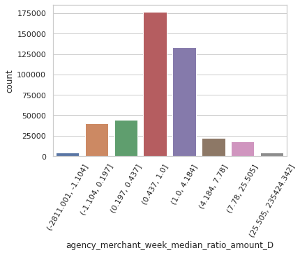

```python
var = 'agency_merchant_week_median_ratio_amount'
binned_var = var + '_D'
percentile = [0,0.01,0.1,0.2,0.5,0.9,0.95,0.99,1]
df8[binned_var] = pd.qcut( df8[var],percentile)
g = sns.countplot(x="agency_merchant_week_median_ratio_amount_D", data=df8)
g.set_xticklabels(g.get_xticklabels(), rotation = 60)
```

Assuming that the top 10% of the agency_merchant_week_median_ratio_amount are credit card fraud (credit card abuse), choose 4 as the benchmark to filter out the following transactions.

```python
df8[df8['agency_merchant_week_median_ratio_amount']>4].head()
```

|  | Year_Month | Agency_Number | Agency_Name | Cardholder_Last_Name | Cardholder_First_Initial | Description | Amount | Vendor | Transaction_Date | Posted_Date | Merchant_Category | Year | Month | Week_Number | Day_of_Week | Median_amount | agency_merchant_week_median_ratio_amount | agency_merchant_week_median_ratio_amount_D |
| --- | --- | --- | --- | --- | --- | --- | --- | --- | --- | --- | --- | --- | --- | --- | --- | --- | --- | --- |
| 14 | 2013-07-01 | 1000 | OKLAHOMA STATE UNIVERSITY | Meints | K | GENERAL PURCHASE | 445.00 | OK DEPT OF VO-TECH ED | 2013-07-30 | 2013-07-31 | GOVERNMENT SERVICES--NOT ELSEWHERE CLASSIFIED | 2013 | 7 | 31 | Tuesday | 65.900 | 6.752656 | (4.184, 7.78] |
| 16 | 2013-07-01 | 1000 | OKLAHOMA STATE UNIVERSITY | Mohiuddin | I | GENERAL PURCHASE | 2425.00 | WESTERN EQUIPMENT ALVA | 2013-07-29 | 2013-07-31 | HARDWARE STORES | 2013 | 7 | 31 | Monday | 76.335 | 31.767865 | (25.505, 235424.342] |
| 17 | 2013-07-01 | 1000 | OKLAHOMA STATE UNIVERSITY | Mohiuddin | I | GENERAL PURCHASE | 2425.00 | WESTERN EQUIPMENT ALVA | 2013-07-29 | 2013-07-31 | HARDWARE STORES | 2013 | 7 | 31 | Monday | 76.335 | 31.767865 | (25.505, 235424.342] |
| 33 | 2013-07-01 | 1000 | OKLAHOMA STATE UNIVERSITY | Gerlt | T | GENERAL PURCHASE | 3582.00 | TELVENT | 2013-07-26 | 2013-07-29 | BUSINESS SERVICES NOT ELSEWHERE CLASSIFIED | 2013 | 7 | 30 | Friday | 199.970 | 17.912687 | (7.78, 25.505] |
| 35 | 2013-07-01 | 1000 | OKLAHOMA STATE UNIVERSITY | GODSEY | R | GENERAL PURCHASE | 407.85 | OPTIMUM ENERGY PROD | 2013-07-26 | 2013-07-29 | HARDWARE STORES | 2013 | 7 | 30 | Friday | 46.500 | 8.770968 | (7.78, 25.505] |

## 9. ratio(mean(Agency_Marchant_Day))

Next, day, a finer time dimension, is used to detect outliers.

```python
stat_by_agency = df.groupby(['Agency_Name', 'Merchant_Category','Transaction_Date'])['Amount'].mean()
stat_by_agency = pd.DataFrame(stat_by_agency)
stat_by_agency.columns = ['AVG_amount']

#add the new feature to the dataset
df9 = pd.merge(df, stat_by_agency, how='left', on=['Agency_Name', 'Merchant_Category','Transaction_Date'])

# Feature 9:
df9['agency_merchant_day_avg_ratio_amount'] = np.where(df9['AVG_amount']==0,0, df9['Amount'] / df9['AVG_amount'])
df9['agency_merchant_day_avg_ratio_amount'].describe()
```

```
count    4.424580e+05
mean     9.975638e-01
std      3.099853e+15
min     -5.875565e+17
25%      3.984064e-01
50%      1.000000e+00
75%      1.086957e+00
max      5.875565e+17
Name: agency_merchant_day_avg_ratio_amount, dtype: float64
```

```
[Text(0, 0, '(-5.875564958853576e+17, -0.838]'),
```

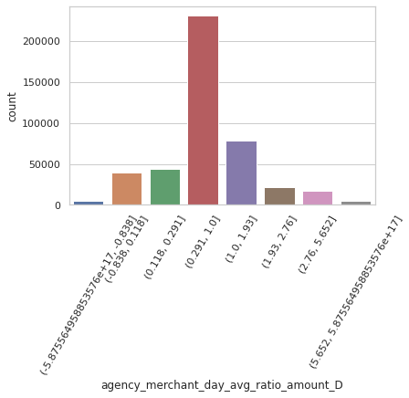

```python
# cut by percentile for plotting
var = 'agency_merchant_day_avg_ratio_amount'
binned_var = var + '_D'
percentile = [0,0.01,0.1,0.2,0.5,0.9,0.95,0.99,1]
df9[binned_var] = pd.qcut(df9[var],percentile)

# Visualization
g = sns.countplot(x="agency_merchant_day_avg_ratio_amount_D", data=df9)
g.set_xticklabels(g.get_xticklabels(), rotation = 60)
```

Assuming that the top 10% of the agency_merchant_day_avg_ratio_amount are credit card fraud (credit card abuse), choose 1.5 as the benchmark to filter out the following transactions.

```python
df9[df9['agency_merchant_day_avg_ratio_amount']>1.5].head()
```

|  | Year_Month | Agency_Number | Agency_Name | Cardholder_Last_Name | Cardholder_First_Initial | Description | Amount | Vendor | Transaction_Date | Posted_Date | Merchant_Category | Year | Month | Week_Number | Day_of_Week | AVG_amount | agency_merchant_day_avg_ratio_amount | agency_merchant_day_avg_ratio_amount_D |
| --- | --- | --- | --- | --- | --- | --- | --- | --- | --- | --- | --- | --- | --- | --- | --- | --- | --- | --- |
| 0 | 2013-07-01 | 1000 | OKLAHOMA STATE UNIVERSITY | Mason | C | GENERAL PURCHASE | 890.00 | NACAS | 2013-07-30 | 2013-07-31 | CHARITABLE AND SOCIAL SERVICE ORGANIZATIONS | 2013 | 7 | 31 | Tuesday | 529.062500 | 1.682221 | (1.0, 1.93] |
| 3 | 2013-07-01 | 1000 | OKLAHOMA STATE UNIVERSITY | Massey | T | GENERAL PURCHASE | 96.39 | WAL-MART #0137 | 2013-07-30 | 2013-07-31 | GROCERY STORES,AND SUPERMARKETS | 2013 | 7 | 31 | Tuesday | 46.278824 | 2.082810 | (1.93, 2.76] |
| 12 | 2013-07-01 | 1000 | OKLAHOMA STATE UNIVERSITY | McLemore | A | GENERAL PURCHASE | 572.27 | GIDDINGS MACHINE CO. | 2013-07-30 | 2013-07-31 | COMMERCIAL EQUIPMENT, NOT ELSEWHERE CLASSIFIED | 2013 | 7 | 31 | Tuesday | 331.055000 | 1.728625 | (1.0, 1.93] |
| 14 | 2013-07-01 | 1000 | OKLAHOMA STATE UNIVERSITY | Meints | K | GENERAL PURCHASE | 445.00 | OK DEPT OF VO-TECH ED | 2013-07-30 | 2013-07-31 | GOVERNMENT SERVICES--NOT ELSEWHERE CLASSIFIED | 2013 | 7 | 31 | Tuesday | 231.000000 | 1.926407 | (1.0, 1.93] |
| 15 | 2013-07-01 | 1000 | OKLAHOMA STATE UNIVERSITY | Mohiuddin | A | GENERAL PURCHASE | 452.91 | TFS THERMOASHEVILLE | 2013-07-31 | 2013-07-31 | DENTAL/LABORATORY/MEDICAL/OPHTHALMIC HOSP EQIP... | 2013 | 7 | 31 | Wednesday | 247.485200 | 1.830049 | (1.0, 1.93] |

## 10. ratio(median(Agency_Marchant_Day))

Similarly, the median is again used to complement the mean.

```python
stat_by_agency = df.groupby(['Agency_Name', 'Merchant_Category','Transaction_Date'])['Amount'].median()
stat_by_agency = pd.DataFrame(stat_by_agency)
stat_by_agency.columns = ['Median_amount']

#add the new feature to the dataset
df10 = pd.merge(df, stat_by_agency, how='left', on=['Agency_Name', 'Merchant_Category','Transaction_Date'])

# Feature 10:
df10['agency_merchant_day_median_ratio_amount'] = np.where(df10['Median_amount']==0,0, df10['Amount'] / df10['Median_amount'])
df10['agency_merchant_day_median_ratio_amount'].describe()
```

```
count    442458.000000
mean          2.558953
std         472.959016
min       -6336.000000
25%           0.750000
50%           1.000000
75%           1.286993
max      314251.342908
Name: agency_merchant_day_median_ratio_amount, dtype: float64
```

```
[Text(0, 0, '(-6336.001, -1.0]'),
```

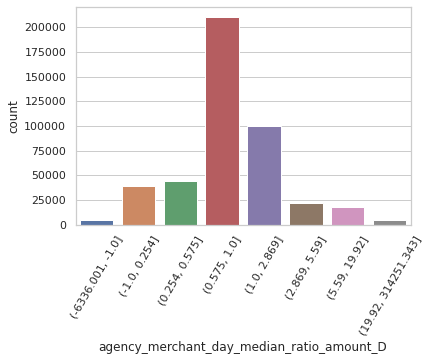

```python
var = 'agency_merchant_day_median_ratio_amount'
binned_var = var + '_D'
percentile = [0,0.01,0.1,0.2,0.5,0.9,0.95,0.99,1]
df10[binned_var] = pd.qcut( df10[var],percentile)
g = sns.countplot(x="agency_merchant_day_median_ratio_amount_D", data=df10)
g.set_xticklabels(g.get_xticklabels(), rotation = 60)
```

Assuming that the top 10% of the agency_merchant_week_median_ratio_amount are credit card fraud (credit card abuse), choose 2.5 as the benchmark to filter out the following transactions.

```python
df10[df10['agency_merchant_day_median_ratio_amount']>2.5].head()
```

|  | Year_Month | Agency_Number | Agency_Name | Cardholder_Last_Name | Cardholder_First_Initial | Description | Amount | Vendor | Transaction_Date | Posted_Date | Merchant_Category | Year | Month | Week_Number | Day_of_Week | Median_amount | agency_merchant_day_median_ratio_amount | agency_merchant_day_median_ratio_amount_D |
| --- | --- | --- | --- | --- | --- | --- | --- | --- | --- | --- | --- | --- | --- | --- | --- | --- | --- | --- |
| 12 | 2013-07-01 | 1000 | OKLAHOMA STATE UNIVERSITY | McLemore | A | GENERAL PURCHASE | 572.27 | GIDDINGS MACHINE CO. | 2013-07-30 | 2013-07-31 | COMMERCIAL EQUIPMENT, NOT ELSEWHERE CLASSIFIED | 2013 | 7 | 31 | Tuesday | 208.815 | 2.740560 | (1.0, 2.869] |
| 15 | 2013-07-01 | 1000 | OKLAHOMA STATE UNIVERSITY | Mohiuddin | A | GENERAL PURCHASE | 452.91 | TFS THERMOASHEVILLE | 2013-07-31 | 2013-07-31 | DENTAL/LABORATORY/MEDICAL/OPHTHALMIC HOSP EQIP... | 2013 | 7 | 31 | Wednesday | 79.100 | 5.725790 | (5.59, 19.92] |
| 16 | 2013-07-01 | 1000 | OKLAHOMA STATE UNIVERSITY | Mohiuddin | I | GENERAL PURCHASE | 2425.00 | WESTERN EQUIPMENT ALVA | 2013-07-29 | 2013-07-31 | HARDWARE STORES | 2013 | 7 | 31 | Monday | 55.830 | 43.435429 | (19.92, 314251.343] |
| 17 | 2013-07-01 | 1000 | OKLAHOMA STATE UNIVERSITY | Mohiuddin | I | GENERAL PURCHASE | 2425.00 | WESTERN EQUIPMENT ALVA | 2013-07-29 | 2013-07-31 | HARDWARE STORES | 2013 | 7 | 31 | Monday | 55.830 | 43.435429 | (19.92, 314251.343] |
| 33 | 2013-07-01 | 1000 | OKLAHOMA STATE UNIVERSITY | Gerlt | T | GENERAL PURCHASE | 3582.00 | TELVENT | 2013-07-26 | 2013-07-29 | BUSINESS SERVICES NOT ELSEWHERE CLASSIFIED | 2013 | 7 | 30 | Friday | 189.000 | 18.952381 | (5.59, 19.92] |

## 11. ratio(median(person_Marchant_Month))

The first 10 indicators mainly compare the consumption of an individual with that of his company. However, everyone's spending habits are vastly different, and some people like to save money while others want to have fun in time, even given the same salary in the same region. Therefore, the next comparison will be made using the individual's consumption as a reference. Although this may filter out some large personal spending, false negative is better than false positive, isn't it?

Since the number of data for calculating the reference values (median) is greatly reduced when using one person, I will only calculate the month and year dimensions to reduce the effect of individual extreme values.

```python
stat_by_person = df.groupby(['Agency_Name','Cardholder_Last_Name', 'Cardholder_First_Initial','Merchant_Category','Month'])['Amount'].median()
stat_by_person = pd.DataFrame(stat_by_person)
stat_by_person.columns = ['AVG_person']

#add the new feature to the dataset
df11 = pd.merge(df, stat_by_person, how='left', on=['Agency_Name','Cardholder_Last_Name', 'Cardholder_First_Initial','Merchant_Category','Month'])

# Feature 11:
df11['person_Month_median_ratio_amount'] = np.where(df11['AVG_person']==0,0, df11['Amount'] / df11['AVG_person'])
df11['person_Month_median_ratio_amount'].describe()
```

```
count    442458.000000
mean          1.181799
std         271.781091
min     -156400.000000
25%           0.851256
50%           1.000000
75%           1.140258
max       63226.000000
Name: person_Month_median_ratio_amount, dtype: float64
```

```
[Text(0, 0, '(-156400.001, -1.0]'),
```

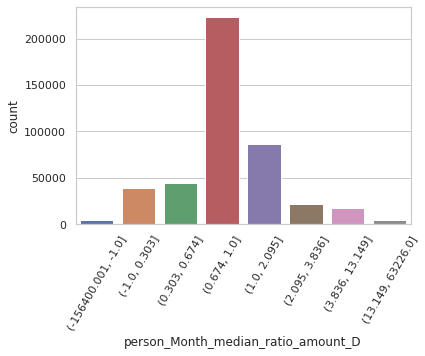

```python
# cut by percentile for plotting
var = 'person_Month_median_ratio_amount'
binned_var = var + '_D'
percentile = [0,0.01,0.1,0.2,0.5,0.9,0.95,0.99,1]
df11[binned_var] = pd.qcut(df11[var],percentile)

# Visualization
g = sns.countplot(x="person_Month_median_ratio_amount_D", data=df11)
g.set_xticklabels(g.get_xticklabels(), rotation = 60)
```

Assuming that the top 5% of the person_Month_median_ratio_amount are credit card fraud (credit card abuse), choose 3.5 as the benchmark to filter out the following transactions.

The reason for adjustung the threshold form 10% to 5% is that the cumulative probability of a person suffering from credit card fraud should be lower. Once discovered once, credit cards are more strictly regulated by both the user and the bank.

```python
df11[df11['person_Month_median_ratio_amount']>3.5].head()
```

|  | Year_Month | Agency_Number | Agency_Name | Cardholder_Last_Name | Cardholder_First_Initial | Description | Amount | Vendor | Transaction_Date | Posted_Date | Merchant_Category | Year | Month | Week_Number | Day_of_Week | AVG_person | person_Month_median_ratio_amount | person_Month_median_ratio_amount_D |
| --- | --- | --- | --- | --- | --- | --- | --- | --- | --- | --- | --- | --- | --- | --- | --- | --- | --- | --- |
| 37 | 2013-07-01 | 1000 | OKLAHOMA STATE UNIVERSITY | Golay | B | MITSUBISHI K-91HG GL CS | 94.64 | FISHER SCI HUS | 2013-07-27 | 2013-07-29 | DENTAL/LABORATORY/MEDICAL/OPHTHALMIC HOSP EQIP... | 2013 | 7 | 30 | Saturday | 23.00 | 4.114783 | (3.836, 13.149] |
| 62 | 2013-07-01 | 1000 | OKLAHOMA STATE UNIVERSITY | Dollins | D | CYLAIRBREATHING300CGA346 MO\|CYLHYDROGENUHPGR5S... | 58.66 | AIRGAS CENTRAL | 2013-07-25 | 2013-07-26 | CHEMICALS AND ALLIED PRODUCTS NOT ELSEWHERE CL... | 2013 | 7 | 30 | Thursday | 4.19 | 14.000000 | (13.149, 63226.0] |
| 63 | 2013-07-01 | 1000 | OKLAHOMA STATE UNIVERSITY | Dollins | D | CYLAIRBREATHING300CGA346 MO\|CYLHELIUMUHP300CGA580 | 25.14 | AIRGAS CENTRAL | 2013-07-25 | 2013-07-26 | CHEMICALS AND ALLIED PRODUCTS NOT ELSEWHERE CL... | 2013 | 7 | 30 | Thursday | 4.19 | 6.000000 | (3.836, 13.149] |
| 78 | 2013-07-01 | 1000 | OKLAHOMA STATE UNIVERSITY | Fokar | M | QIAPREP SPIN MINIPREP KIT KIT\|RNEASY MINI PLAN... | 1943.29 | QIAGEN INC | 2013-07-26 | 2013-07-26 | DENTAL/LABORATORY/MEDICAL/OPHTHALMIC HOSP EQIP... | 2013 | 7 | 30 | Friday | 379.52 | 5.120389 | (3.836, 13.149] |
| 87 | 2013-07-01 | 1000 | OKLAHOMA STATE UNIVERSITY | Robinson | D | GENERAL PURCHASE | 390.00 | NATIONAL SOCCER COACHES A | 2013-07-29 | 2013-07-31 | SCHOOLS AND EDUCATIONAL SERVICES NOT ELSEWHERE... | 2013 | 7 | 31 | Monday | 85.00 | 4.588235 | (3.836, 13.149] |

## 12. ratio(median(person_Marchant_Year))

```python
stat_by_person = df.groupby(['Agency_Name','Cardholder_Last_Name', 'Cardholder_First_Initial','Merchant_Category','Year'])['Amount'].median()
stat_by_person = pd.DataFrame(stat_by_person)
stat_by_person.columns = ['AVG_person']

#add the new feature to the dataset
df12 = pd.merge(df, stat_by_person, how='left', on=['Agency_Name','Cardholder_Last_Name', 'Cardholder_First_Initial','Merchant_Category','Year'])

# Feature 12:
df12['person_year_median_ratio_amount'] = np.where(df12['AVG_person']==0,0, df12['Amount'] / df12['AVG_person'])
df12['person_year_median_ratio_amount'].describe()
```

```
count    442458.000000
mean          1.414815
std         179.537677
min     -102375.000000
25%           0.666614
50%           1.000000
75%           1.408180
max       13119.000000
Name: person_year_median_ratio_amount, dtype: float64
```

```
[Text(0, 0, '(-102375.001, -1.05]'),
```

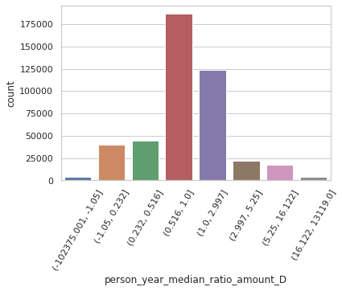

```python
# cut by percentile for plotting
var = 'person_year_median_ratio_amount'
binned_var = var + '_D'
percentile = [0,0.01,0.1,0.2,0.5,0.9,0.95,0.99,1]
df12[binned_var] = pd.qcut(df12[var],percentile)

# Visualization
g = sns.countplot(x="person_year_median_ratio_amount_D", data=df12)
g.set_xticklabels(g.get_xticklabels(), rotation = 60)
```

Assuming that the top 5% of the person_year_median_ratio_amount are credit card fraud (credit card abuse), choose 5 as the benchmark to filter out the following transactions.

```python
df12[df12['person_year_median_ratio_amount']>5].head()
```

|  | Year_Month | Agency_Number | Agency_Name | Cardholder_Last_Name | Cardholder_First_Initial | Description | Amount | Vendor | Transaction_Date | Posted_Date | Merchant_Category | Year | Month | Week_Number | Day_of_Week | AVG_person | person_year_median_ratio_amount | person_year_median_ratio_amount_D |
| --- | --- | --- | --- | --- | --- | --- | --- | --- | --- | --- | --- | --- | --- | --- | --- | --- | --- | --- |
| 50 | 2013-07-01 | 1000 | OKLAHOMA STATE UNIVERSITY | Davis | G | Disposable GlovesNitrile EA\|Ear Plugs32dBW/o C... | 714.94 | WW GRAINGER | 2013-07-24 | 2013-07-26 | INDUSTRIAL SUPPLIES NOT ELSEWHERE CLASSIFIED | 2013 | 7 | 30 | Wednesday | 88.850 | 8.046595 | (5.25, 16.122] |
| 62 | 2013-07-01 | 1000 | OKLAHOMA STATE UNIVERSITY | Dollins | D | CYLAIRBREATHING300CGA346 MO\|CYLHYDROGENUHPGR5S... | 58.66 | AIRGAS CENTRAL | 2013-07-25 | 2013-07-26 | CHEMICALS AND ALLIED PRODUCTS NOT ELSEWHERE CL... | 2013 | 7 | 30 | Thursday | 4.190 | 14.000000 | (5.25, 16.122] |
| 63 | 2013-07-01 | 1000 | OKLAHOMA STATE UNIVERSITY | Dollins | D | CYLAIRBREATHING300CGA346 MO\|CYLHELIUMUHP300CGA580 | 25.14 | AIRGAS CENTRAL | 2013-07-25 | 2013-07-26 | CHEMICALS AND ALLIED PRODUCTS NOT ELSEWHERE CL... | 2013 | 7 | 30 | Thursday | 4.190 | 6.000000 | (5.25, 16.122] |
| 78 | 2013-07-01 | 1000 | OKLAHOMA STATE UNIVERSITY | Fokar | M | QIAPREP SPIN MINIPREP KIT KIT\|RNEASY MINI PLAN... | 1943.29 | QIAGEN INC | 2013-07-26 | 2013-07-26 | DENTAL/LABORATORY/MEDICAL/OPHTHALMIC HOSP EQIP... | 2013 | 7 | 30 | Friday | 229.710 | 8.459754 | (5.25, 16.122] |
| 108 | 2013-07-01 | 1000 | OKLAHOMA STATE UNIVERSITY | Haseley | S | GENERAL PURCHASE | 571.68 | WAL-MART #4241 | 2013-07-28 | 2013-07-29 | GROCERY STORES,AND SUPERMARKETS | 2013 | 7 | 30 | Sunday | 46.865 | 12.198442 | (5.25, 16.122] |

## 13. ratio(mean(person_Marchant_Month))

```python
stat_by_person = df.groupby(['Agency_Name','Cardholder_Last_Name', 'Cardholder_First_Initial','Merchant_Category','Month'])['Amount'].mean()
stat_by_person = pd.DataFrame(stat_by_person)
stat_by_person.columns = ['AVG_person']

#add the new feature to the dataset
df15 = pd.merge(df, stat_by_person, how='left', on=['Agency_Name','Cardholder_Last_Name', 'Cardholder_First_Initial','Merchant_Category','Month'])

# Feature 15:
df15['person_Month_mean_ratio_amount'] = np.where(df15['AVG_person']==0,0, df15['Amount'] / df15['AVG_person'])
df15['person_Month_mean_ratio_amount'].describe()
```

```
count    4.424580e+05
mean     9.958415e-01
std      4.487573e+14
min     -1.266826e+17
25%      5.746676e-01
50%      1.000000e+00
75%      1.092573e+00
max      1.263193e+17
Name: person_Month_mean_ratio_amount, dtype: float64
```

```
[Text(0, 0, '(-1.2668256604282766e+17, -1.0]'),
```

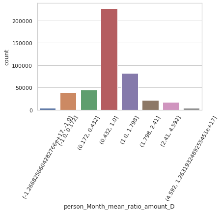

```python
# cut by percentile for plotting
var = 'person_Month_mean_ratio_amount'
binned_var = var + '_D'
percentile = [0,0.01,0.1,0.2,0.5,0.9,0.95,0.99,1]
df15[binned_var] = pd.qcut(df15[var],percentile)

# Visualization
g = sns.countplot(x="person_Month_mean_ratio_amount_D", data=df15)
g.set_xticklabels(g.get_xticklabels(), rotation = 60)
```

Assuming that the top 5% of the person_Month_mean_ratio_amount are credit card fraud (credit card abuse), choose 2.4 as the benchmark to filter out the following transactions.

```python
df15[df15['person_Month_mean_ratio_amount']>2.4].head()
```

|  | Year_Month | Agency_Number | Agency_Name | Cardholder_Last_Name | Cardholder_First_Initial | Description | Amount | Vendor | Transaction_Date | Posted_Date | Merchant_Category | Year | Month | Week_Number | Day_of_Week | AVG_person | person_Month_mean_ratio_amount | person_Month_mean_ratio_amount_D |
| --- | --- | --- | --- | --- | --- | --- | --- | --- | --- | --- | --- | --- | --- | --- | --- | --- | --- | --- |
| 26 | 2013-07-01 | 1000 | OKLAHOMA STATE UNIVERSITY | Foye | S | GENERAL PURCHASE | 178.00 | AFFYMETRIX, INC | 2013-07-26 | 2013-07-29 | DENTAL/LABORATORY/MEDICAL/OPHTHALMIC HOSP EQIP... | 2013 | 7 | 30 | Friday | 74.000000 | 2.405405 | (1.798, 2.41] |
| 62 | 2013-07-01 | 1000 | OKLAHOMA STATE UNIVERSITY | Dollins | D | CYLAIRBREATHING300CGA346 MO\|CYLHYDROGENUHPGR5S... | 58.66 | AIRGAS CENTRAL | 2013-07-25 | 2013-07-26 | CHEMICALS AND ALLIED PRODUCTS NOT ELSEWHERE CL... | 2013 | 7 | 30 | Thursday | 19.274000 | 3.043478 | (2.41, 4.592] |
| 78 | 2013-07-01 | 1000 | OKLAHOMA STATE UNIVERSITY | Fokar | M | QIAPREP SPIN MINIPREP KIT KIT\|RNEASY MINI PLAN... | 1943.29 | QIAGEN INC | 2013-07-26 | 2013-07-26 | DENTAL/LABORATORY/MEDICAL/OPHTHALMIC HOSP EQIP... | 2013 | 7 | 30 | Friday | 615.455000 | 3.157485 | (2.41, 4.592] |
| 108 | 2013-07-01 | 1000 | OKLAHOMA STATE UNIVERSITY | Haseley | S | GENERAL PURCHASE | 571.68 | WAL-MART #4241 | 2013-07-28 | 2013-07-29 | GROCERY STORES,AND SUPERMARKETS | 2013 | 7 | 30 | Sunday | 171.567500 | 3.332100 | (2.41, 4.592] |
| 111 | 2013-07-01 | 1000 | OKLAHOMA STATE UNIVERSITY | Heaton | D | GENERAL PURCHASE | 335.84 | FENTON OFFICE SUP01 OF 01 | 2013-07-25 | 2013-07-29 | STATIONERY, OFFICE SUPPLIES, PRINTING AND WRIT... | 2013 | 7 | 30 | Thursday | 120.022857 | 2.798134 | (2.41, 4.592] |

## 14. Days_since_last(Agency_Vendor)

This metric is **new** and is intended to measure the time interval between each user's last two purchases under the same vendor. It also screens out those with too large an interval to measure as potential abnormal consumption. This metric can be used to identify credit card fraud from the **perspective of spending recency**.

In addition, the first time a purchase is made with a new vendor could also be fraudulent. However, since most of the "first-time purchases" should be normal purchases by the user. To avoid excessive errors, it is not selected separately here. However, the *agency_vendor_days_since_last* indicator for the first purchase is set to -1 for subsequent modeling purposes.

```python
df13 = df.copy()
df13['agency_vendor_days_since_last'] = df.sort_values(['Agency_Name','Vendor','Transaction_Date']).groupby(['Agency_Name','Vendor'])['Transaction_Date'].diff().dt.days.fillna(-1)
df13 = pd.DataFrame(df13)
df13.tail()
```

|  | Year_Month | Agency_Number | Agency_Name | Cardholder_Last_Name | Cardholder_First_Initial | Description | Amount | Vendor | Transaction_Date | Posted_Date | Merchant_Category | Year | Month | Week_Number | Day_of_Week | agency_vendor_days_since_last |
| --- | --- | --- | --- | --- | --- | --- | --- | --- | --- | --- | --- | --- | --- | --- | --- | --- |
| 442453 | 2014-06-01 | 98000 | GRAND RIVER DAM AUTH. | Cardholder | e | GENERAL PURCHASE | 992.00 | TOTAL VALVE SYSTEMS | 2014-06-20 | 2014-06-23 | HARDWARE EQUIPMENT AND SUPPLIES | 2014 | 6 | 25 | Friday | 4.0 |
| 442454 | 2014-06-01 | 98000 | GRAND RIVER DAM AUTH. | Cardholder | e | GENERAL PURCHASE | 2415.00 | PRYOR WASTE & RECYCLING L | 2014-06-20 | 2014-06-23 | UTILITIES - ELECTRIC,GAS,WATER,SANITARY | 2014 | 6 | 25 | Friday | 3.0 |
| 442455 | 2014-06-01 | 98000 | GRAND RIVER DAM AUTH. | Cardholder | e | GENERAL PURCHASE | 177.50 | ACCURATE ENVIROMENTAL LAB | 2014-06-20 | 2014-06-23 | BUSINESS SERVICES NOT ELSEWHERE CLASSIFIED | 2014 | 6 | 25 | Friday | 4.0 |
| 442456 | 2014-06-01 | 98000 | GRAND RIVER DAM AUTH. | Cardholder | e | GENERAL PURCHASE | 32457.00 | RED BUD SERVICE INC | 2014-06-19 | 2014-06-23 | PROFESSIONAL SERVICES NOT ELSEWHERE CLASSIFIED | 2014 | 6 | 25 | Thursday | 3.0 |
| 442457 | 2014-06-01 | 98000 | GRAND RIVER DAM AUTH. | Cardholder | e | GENERAL PURCHASE | 4714.07 | WARRENCAT CREDIT DEPT | 2014-06-20 | 2014-06-23 | MISCELLANEOUS AND SPECIALTY RETAIL STORES | 2014 | 6 | 25 | Friday | 14.0 |

```python
df13['agency_vendor_days_since_last'].describe()
```

```
count    442458.000000
mean          9.938952
std          30.078321
min          -1.000000
25%          -1.000000
50%           0.000000
75%           5.000000
max         364.000000
Name: agency_vendor_days_since_last, dtype: float64
```

```
[Text(0, 0, '[-1, 0)'),
```

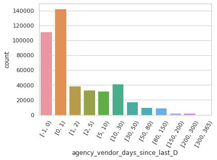

```python
# cut by days
var = 'agency_vendor_days_since_last'
binned_var = var + '_D'
percentile = [-1,0,1,2,5,10,30,50,80,150,200,300,365]
df13[binned_var] = pd.cut(df13[var],percentile,include_lowest = True, right=False)

# Visualization
g = sns.countplot(x="agency_vendor_days_since_last_D", data=df13)
g.set_xticklabels(g.get_xticklabels(), rotation = 60)
```

```python
df13[df13['agency_vendor_days_since_last']>150].head()
```

|  | Year_Month | Agency_Number | Agency_Name | Cardholder_Last_Name | Cardholder_First_Initial | Description | Amount | Vendor | Transaction_Date | Posted_Date | Merchant_Category | Year | Month | Week_Number | Day_of_Week | agency_vendor_days_since_last | agency_vendor_days_since_last_D |
| --- | --- | --- | --- | --- | --- | --- | --- | --- | --- | --- | --- | --- | --- | --- | --- | --- | --- |
| 48131 | 2013-11-01 | 1000 | OKLAHOMA STATE UNIVERSITY | Woodward | K | GENERAL PURCHASE | 245.00 | THE ELECTRIC SCOOTER STOR | 2013-11-27 | 2013-11-29 | DENTAL/LABORATORY/MEDICAL/OPHTHALMIC HOSP EQIP... | 2013 | 11 | 48 | Wednesday | 152.0 | [150, 200) |
| 50141 | 2013-12-01 | 1000 | OKLAHOMA STATE UNIVERSITY | Nazari Chamaki | S | GENERAL PURCHASE | 450.00 | ASABE | 2013-12-18 | 2013-12-19 | ARCHITECTURAL,ENGINEERING,AND SURVEYING SERVICES | 2013 | 12 | 51 | Wednesday | 160.0 | [150, 200) |
| 50171 | 2013-12-01 | 1000 | OKLAHOMA STATE UNIVERSITY | Gerlt | T | GENERAL PURCHASE | 750.00 | IMPACT APPLICATION | 2013-12-17 | 2013-12-17 | MEDICAL SERVICES & HEALTH PRACTITIONERS NOT EL... | 2013 | 12 | 51 | Tuesday | 152.0 | [150, 200) |
| 50677 | 2013-12-01 | 1000 | OKLAHOMA STATE UNIVERSITY | Annuschat | D | GENERAL PURCHASE | 150.00 | NATES TREE SERVICE LLC | 2013-12-18 | 2013-12-20 | PROFESSIONAL SERVICES NOT ELSEWHERE CLASSIFIED | 2013 | 12 | 51 | Wednesday | 155.0 | [150, 200) |
| 50683 | 2013-12-01 | 1000 | OKLAHOMA STATE UNIVERSITY | Baumann | J | ROOM CHARGES | -215.37 | HILTON GARDEN INN TULS | 2013-12-06 | 2013-12-20 | HILTON GARDEN INN | 2013 | 12 | 49 | Friday | 155.0 | [150, 200) |

## 15. Days_since_last(Agency_Merchant)

```python
df14 = df.copy()
df14['agency_Marchant_days_since_last'] = df.sort_values(['Agency_Name','Merchant_Category','Transaction_Date']).groupby(['Agency_Name','Merchant_Category'])['Transaction_Date'].diff().dt.days.fillna(-1)
df14 = pd.DataFrame(df14)
df14.tail()
```

|  | Year_Month | Agency_Number | Agency_Name | Cardholder_Last_Name | Cardholder_First_Initial | Description | Amount | Vendor | Transaction_Date | Posted_Date | Merchant_Category | Year | Month | Week_Number | Day_of_Week | agency_Marchant_days_since_last |
| --- | --- | --- | --- | --- | --- | --- | --- | --- | --- | --- | --- | --- | --- | --- | --- | --- |
| 442453 | 2014-06-01 | 98000 | GRAND RIVER DAM AUTH. | Cardholder | e | GENERAL PURCHASE | 992.00 | TOTAL VALVE SYSTEMS | 2014-06-20 | 2014-06-23 | HARDWARE EQUIPMENT AND SUPPLIES | 2014 | 6 | 25 | Friday | 4.0 |
| 442454 | 2014-06-01 | 98000 | GRAND RIVER DAM AUTH. | Cardholder | e | GENERAL PURCHASE | 2415.00 | PRYOR WASTE & RECYCLING L | 2014-06-20 | 2014-06-23 | UTILITIES - ELECTRIC,GAS,WATER,SANITARY | 2014 | 6 | 25 | Friday | 0.0 |
| 442455 | 2014-06-01 | 98000 | GRAND RIVER DAM AUTH. | Cardholder | e | GENERAL PURCHASE | 177.50 | ACCURATE ENVIROMENTAL LAB | 2014-06-20 | 2014-06-23 | BUSINESS SERVICES NOT ELSEWHERE CLASSIFIED | 2014 | 6 | 25 | Friday | 1.0 |
| 442456 | 2014-06-01 | 98000 | GRAND RIVER DAM AUTH. | Cardholder | e | GENERAL PURCHASE | 32457.00 | RED BUD SERVICE INC | 2014-06-19 | 2014-06-23 | PROFESSIONAL SERVICES NOT ELSEWHERE CLASSIFIED | 2014 | 6 | 25 | Thursday | 0.0 |
| 442457 | 2014-06-01 | 98000 | GRAND RIVER DAM AUTH. | Cardholder | e | GENERAL PURCHASE | 4714.07 | WARRENCAT CREDIT DEPT | 2014-06-20 | 2014-06-23 | MISCELLANEOUS AND SPECIALTY RETAIL STORES | 2014 | 6 | 25 | Friday | 0.0 |

```python
df14['agency_Marchant_days_since_last'].describe()
```

```
count    442458.000000
mean          3.261428
std          14.320399
min          -1.000000
25%           0.000000
50%           0.000000
75%           1.000000
max         357.000000
Name: agency_Marchant_days_since_last, dtype: float64
```

```
[Text(0, 0, '[-1, 0)'),
```

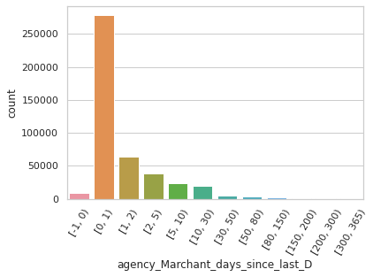

```python
# cut by days
var = 'agency_Marchant_days_since_last'
binned_var = var + '_D'
percentile = [-1,0,1,2,5,10,30,50,80,150,200,300,365]
df14[binned_var] = pd.cut(df14[var],percentile,include_lowest = True, right=False)

# Visualization
g = sns.countplot(x="agency_Marchant_days_since_last_D", data=df14)
g.set_xticklabels(g.get_xticklabels(), rotation = 60)
```

```python
df14[df14['agency_Marchant_days_since_last']>30].head()
```

|  | Year_Month | Agency_Number | Agency_Name | Cardholder_Last_Name | Cardholder_First_Initial | Description | Amount | Vendor | Transaction_Date | Posted_Date | Merchant_Category | Year | Month | Week_Number | Day_of_Week | agency_Marchant_days_since_last | agency_Marchant_days_since_last_D |
| --- | --- | --- | --- | --- | --- | --- | --- | --- | --- | --- | --- | --- | --- | --- | --- | --- | --- |
| 503 | 2013-07-01 | 1000 | OKLAHOMA STATE UNIVERSITY | Jaroni | D | ROOM CHARGES | 233.38 | OMNI CHARLOTTE | 2013-07-29 | 2013-07-30 | OMNI INTERNATIONAL | 2013 | 7 | 31 | Monday | 31.0 | [30, 50) |
| 1566 | 2013-07-01 | 1000 | OKLAHOMA STATE UNIVERSITY | DeRaps | M | GENERAL PURCHASE | -215.00 | CEDAR CREEK FARMS LLC | 2013-06-28 | 2013-07-02 | LODGING--HOTELS,MOTELS,AND RESORTS | 2013 | 7 | 26 | Friday | 43.0 | [30, 50) |
| 3673 | 2013-07-01 | 1000 | OKLAHOMA STATE UNIVERSITY | Massey | T | GENERAL PURCHASE | -3.40 | HYATT HOTELS MNPLS | 2013-06-27 | 2013-07-01 | HYATT HOTELS/INT'L | 2013 | 7 | 26 | Thursday | 37.0 | [30, 50) |
| 3793 | 2013-07-01 | 1000 | OKLAHOMA STATE UNIVERSITY | Mason | C | ROOM CHARGES | 285.00 | AMERICAS BEST VALUE INN | 2013-06-29 | 2013-07-01 | AMERICAS BEST VALUE INN | 2013 | 7 | 26 | Saturday | 38.0 | [30, 50) |
| 4113 | 2013-07-01 | 1000 | OKLAHOMA STATE UNIVERSITY | Brown | P | BATTERYLITHIUMAA4/PAC NMB\|HOLDERBUSINESS CARD ... | 684.02 | OFFICE DEPOT #1079 | 2013-06-27 | 2013-07-01 | COMBINATION CATALOG AND RETAIL MERCHANT | 2013 | 7 | 26 | Thursday | 71.0 | [50, 80) |

# 4. merge

After creating the features, they need to be merged into the same table for modeling purposes.

```python
df_final = pd.merge(df, df1['agency_merchant_avg_ratio_amount'],how='left', left_index=True, right_index=True).\
              merge(df2['agency_merchant_median_ratio_amount'],how='left', left_index=True, right_index=True).\
              merge(df3['agency_merchant_month_avg_ratio_amount'],how='left', left_index=True, right_index=True).\
              merge(df4['agency_merchant_month_median_ratio_amount'],how='left', left_index=True, right_index=True).\
              merge(df5['agency_merchant_year_avg_ratio_amount'],how='left', left_index=True, right_index=True).\
              merge(df6['agency_merchant_year_median_ratio_amount'],how='left', left_index=True, right_index=True).\
              merge(df7['agency_merchant_week_avg_ratio_amount'],how='left', left_index=True, right_index=True).\
              merge(df8['agency_merchant_week_median_ratio_amount'],how='left', left_index=True, right_index=True).\
              merge(df9['agency_merchant_day_avg_ratio_amount'],how='left', left_index=True, right_index=True).\
              merge(df10['agency_merchant_day_median_ratio_amount'],how='left', left_index=True, right_index=True).\
              merge(df11['person_Month_median_ratio_amount'],how='left', left_index=True, right_index=True).\
              merge(df12['person_year_median_ratio_amount'],how='left', left_index=True, right_index=True).\
              merge(df13['agency_vendor_days_since_last'],how='left', left_index=True, right_index=True).\
              merge(df14['agency_Marchant_days_since_last'],how='left', left_index=True, right_index=True).\
              merge(df15['person_Month_mean_ratio_amount'],how='left', left_index=True, right_index=True)
```

# 5. Modeling

**Steps:**

1. Merge 15 features
2. Select variables
3. Split dataset into training and testing
4. Standardize
5. Apply KNN model
6. Clustering
7. Analysis

Since the dataset has no target variable(y), I would like to split X variables, and apply **unsupervised K-nearest Neighbors Algorithm (KNN) models** to identify the anomalies.

**Explain:**

Unsupervised K-nearest Neighbors Algorithm (KNN) model **computes the Euclidean distance of an observation to neighbors.** It can help analysts find outliers by identifying the higher outlier scores.

Here are the methods:

```python
# Check columns' name and enable to select them by names
df_final.columns
```

```
Index(['Year_Month', 'Agency_Number', 'Agency_Name', 'Cardholder_Last_Name',
       'Cardholder_First_Initial', 'Description', 'Amount', 'Vendor',
       'Transaction_Date', 'Posted_Date', 'Merchant_Category', 'Year', 'Month',
       'Week_Number', 'Day_of_Week', 'agency_merchant_avg_ratio_amount',
       'agency_merchant_median_ratio_amount',
       'agency_merchant_month_avg_ratio_amount',
       'agency_merchant_month_median_ratio_amount',
       'agency_merchant_year_avg_ratio_amount',
       'agency_merchant_year_median_ratio_amount',
       'agency_merchant_week_avg_ratio_amount',
       'agency_merchant_week_median_ratio_amount',
       'agency_merchant_day_avg_ratio_amount',
       'agency_merchant_day_median_ratio_amount',
       'person_Month_median_ratio_amount', 'person_year_median_ratio_amount',
       'agency_vendor_days_since_last', 'agency_Marchant_days_since_last',
       'person_Month_mean_ratio_amount'],
      dtype='object')
```

```python
# Only keep the 15 features
df_final = df_final.drop(['Year_Month', 'Agency_Number', 'Agency_Name', 'Cardholder_Last_Name',
       'Cardholder_First_Initial', 'Description', 'Amount', 'Vendor',
       'Transaction_Date', 'Posted_Date', 'Merchant_Category', 'Year', 'Month',
       'Week_Number', 'Day_of_Week'], axis=1)
```

```python
#! pip install pyod
```

Based on the previous study, I realized that it is very important to **split** the original dataset and **normalize** the data before building the model. This simplifies the coefficients of the corresponding equations of the model and enables model overfitting detection.

```python
# Split Data
from sklearn.model_selection import train_test_split
X_train, X_test = train_test_split(df_final,random_state=0)

# Standardize data
from pyod.utils.utility import standardizer
X_train, X_test = standardizer(X_train, X_test)
```

## 5.1 Apply KNN

After processing the dataset, this step is to train the training dataset using the KNN model and apply the computed model to the detection set. The y-value represents the "score", which is **the average distance of each data point from the surrounding data points.** When the y-value exceeds a set threshold, the data point is considered as an outlier.

```python
import numpy as np
import matplotlib.pyplot as plt

# train kNN detector
from pyod.models.knn import KNN
clf_name = 'KNN'
clf = KNN()
clf.fit(X_train)

y_train_scores = clf.decision_scores_
```

```python
# Apply to test dataset
y_test_pred = clf.predict(X_test)
unique, counts = np.unique(y_test_pred, return_counts=True)
dict(zip(unique, counts))
y_test_scores = clf.decision_function(X_test)
```

## 5.2 Cluster

The next step is to classify the dataset based on the y-values calculated in the previous step.

Here, I assume that the outliers are the data points located in the **top 5%** of the average distance(y). Through iterative attempts, I set the **threshold to 0.06**.

```python
# Clustering
df_test = pd.DataFrame(X_test)
df_test['score'] = y_test_scores
df_test['cluster'] = np.where(df_test['score']<0.06, 0, 1)
df_test['cluster'].value_counts()
# Now let's show the summary statistics:
df_test.groupby('cluster').mean()
```

| cluster | 0 | 1 | 2 | 3 | 4 | 5 | 6 | 7 | 8 | 9 | 10 | 11 | 12 | 13 | 14 | score |
| --- | --- | --- | --- | --- | --- | --- | --- | --- | --- | --- | --- | --- | --- | --- | --- | --- |
| 0 | -0.023340 | -0.003079 | 0.001736 | -0.002910 | 0.000785 | -0.002681 | 0.000651 | -0.003540 | 0.000739 | -0.002327 | 0.000712 | 0.000440 | -0.105419 | -0.079508 | 0.000218 | 0.005637 |
| 1 | 0.384337 | 0.007178 | 0.098895 | 0.004872 | 0.044707 | 0.006840 | 0.037059 | 0.011584 | 0.042125 | 0.009062 | 0.015843 | 0.022966 | 1.827964 | 1.451016 | 0.012402 | 0.493998 |

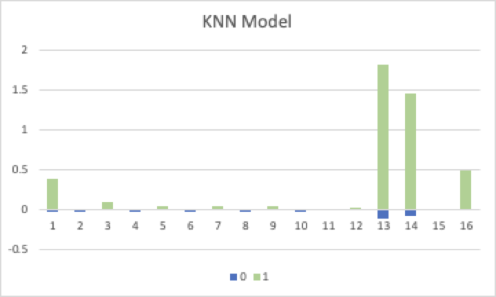

I applied the KNN model built from the training dataset to the test dataset.

In addition, it is not difficult to find that **the average distance(y) of cluster1 under each feature is significantly larger** than that of cluster0. It indicates that this is a good modeling and no modification is needed for individual features.

```python
culster_1 = df_test[df_test['cluster']==1]['cluster'].count() / df_test['cluster'].count() * 100
culster_1
```

```
5.360032545314831
```

```python
cluster_0 = df_test[df_test['cluster']==0]['cluster'].count() / df_test['cluster'].count() * 100
cluster_0
```

```
94.63996745468518
```

# 6. Aggregating Models

In order to test the quality of the 15 features, the next step will be to further test them by building 5 KNN models and by looking at the average, maximum of maximum, average of maximum, and maximum of average. If the following results are similar in the number (percentage) of outliers with the same threshold set, the quality of the 15 features is good, and vice versa.

```python
#!pip install combo
```

```python
from pyod.models.combination import aom, moa, average, maximization
# Split Data
from sklearn.model_selection import train_test_split
X_train, X_test = train_test_split(df_final,random_state=0)

# Standardize data
X_train_norm, X_test_norm = standardizer(X_train, X_test)
```

In each of the 5 KNN models, the average distance between each data point and the surrounding [10, 50, 100, 150, 200] points is calculated as the y-value. Similarly, the original dataset needs to be split and normalized here first.

```python
# Build 5 KNN models
# Test k-neighbors from 10 to 200
n_clf = 5
k_list = [10, 50, 100, 150, 200]

# Prepare data frames
train_scores = np.zeros([X_train.shape[0], n_clf])
test_scores = np.zeros([X_test.shape[0], n_clf])
train_scores.shape

# Modeling
for i in range(n_clf):
    k = k_list[i]
    clf = KNN(n_neighbors=k, method='largest')
    clf.fit(X_train_norm)

    # Store the results in each column:
    train_scores[:, i] = clf.decision_scores_
    test_scores[:, i] = clf.decision_function(X_test_norm)
# Decision scores have to be normalized before combination
train_scores_norm, test_scores_norm = standardizer(train_scores,test_scores)
```

The following indicators are calculated by using the corresponding functions in the PyOD package.

## 6.1 Average

Here, I also assume that the outliers are the data points located in the **top 5%** of the average distance(y). Through several attempts, I set the **threshold to 0.02**.

```python
y_by_average = average(test_scores_norm)
df_test = pd.DataFrame(X_test_norm)
df_test['y_by_average_score'] = y_by_average
df_test['y_by_average_cluster'] = np.where(df_test['y_by_average_score']<0.02, 0, 1)
df_test['y_by_average_cluster'].value_counts()
df_test.groupby('y_by_average_cluster').mean()
```

| y_by_average_cluster | 0 | 1 | 2 | 3 | 4 | 5 | 6 | 7 | 8 | 9 | 10 | 11 | 12 | 13 | 14 | y_by_average_score |
| --- | --- | --- | --- | --- | --- | --- | --- | --- | --- | --- | --- | --- | --- | --- | --- | --- |
| 0 | -0.020246 | -0.002991 | 0.001736 | -0.002832 | 0.000785 | -0.002596 | 0.000651 | -0.003372 | 0.000739 | -0.002210 | 0.000860 | 0.000750 | -0.117291 | -0.104914 | 0.000218 | -0.018087 |
| 1 | 0.344987 | 0.006009 | 0.103137 | 0.003760 | 0.046625 | 0.005674 | 0.038649 | 0.009136 | 0.043932 | 0.007406 | 0.013772 | 0.018218 | 2.131655 | 1.987104 | 0.012934 | 0.245519 |

```python
culster_1 = df_test[df_test['y_by_average_cluster']==1]['y_by_average_cluster'].count() / df_test['y_by_average_cluster'].count() * 100
culster_1
```

```
5.135831487592099
```

Similar to the results calculated for one of the KNN models above, **the average distance(y) of cluster1 under each feature is significantly larger** than that of cluster0. It indicates that this is a good modeling.

## 6.2 The Maximum of Maximum (MOM)

Consistent with the threshold value for screening outliers under the mean, the threshold value was set to 0.02.

```python
# Combination by mom
y_by_maximization = maximization(test_scores_norm)
df_test = pd.DataFrame(X_test_norm)
df_test['y_by_maximization_score'] = y_by_maximization
df_test['y_by_maximization_cluster'] = np.where(df_test['y_by_maximization_score']<0.02, 0, 1)
df_test['y_by_maximization_cluster'].value_counts()
df_test.groupby('y_by_maximization_cluster').mean()
```

| y_by_maximization_cluster | 0 | 1 | 2 | 3 | 4 | 5 | 6 | 7 | 8 | 9 | 10 | 11 | 12 | 13 | 14 | y_by_maximization_score |
| --- | --- | --- | --- | --- | --- | --- | --- | --- | --- | --- | --- | --- | --- | --- | --- | --- |
| 0 | -0.021808 | -0.003019 | 0.001736 | -0.002853 | 0.000785 | -0.002624 | 0.000651 | -0.003407 | 0.000739 | -0.002233 | 0.000841 | 0.000701 | -0.142710 | -0.120349 | 0.000218 | -0.012371 |
| 1 | 0.292408 | 0.004552 | 0.082270 | 0.002710 | 0.037191 | 0.004374 | 0.030829 | 0.007060 | 0.035043 | 0.005755 | 0.011394 | 0.015332 | 2.036505 | 1.779844 | 0.010317 | 0.248759 |

```python
culster_1 = df_test[df_test['y_by_maximization_cluster']==1]['y_by_maximization_cluster'].count() / df_test['y_by_maximization_score'].count() * 100
culster_1
```

```
6.466573249559282
```

Once again, the results calculated for one of the KNN models above, **the average distance(y) of cluster1 under each feature is significantly larger** than that of cluster0. It indicates that this is a good modeling.

However, the percentage of outliers are slightly more than Average metric.

## 6.3: The Average of Maximum (AOM)

Consistent with the threshold value for screening outliers under the mean, the threshold value was set to 0.02.

```python
# Combination by aom
y_by_aom = aom(test_scores_norm)
df_test = pd.DataFrame(X_test_norm)
df_test['y_by_aom_score'] = y_by_aom
df_test['y_by_aom_cluster'] = np.where(df_test['y_by_aom_score']<0.02, 0, 1)
df_test['y_by_aom_cluster'].value_counts()
df_test.groupby('y_by_aom_cluster').mean()
```

| y_by_aom_cluster | 0 | 1 | 2 | 3 | 4 | 5 | 6 | 7 | 8 | 9 | 10 | 11 | 12 | 13 | 14 | y_by_aom_score |
| --- | --- | --- | --- | --- | --- | --- | --- | --- | --- | --- | --- | --- | --- | --- | --- | --- |
| 0 | -0.020246 | -0.002991 | 0.001736 | -0.002832 | 0.000785 | -0.002596 | 0.000651 | -0.003372 | 0.000739 | -0.002210 | 0.000860 | 0.000750 | -0.117291 | -0.104914 | 0.000218 | -0.018087 |
| 1 | 0.344987 | 0.006009 | 0.103137 | 0.003760 | 0.046625 | 0.005674 | 0.038649 | 0.009136 | 0.043932 | 0.007406 | 0.013772 | 0.018218 | 2.131655 | 1.987104 | 0.012934 | 0.245519 |

```python
culster_1 = df_test[df_test['y_by_aom_cluster']==1]['y_by_aom_cluster'].count() / df_test['y_by_aom_cluster'].count() * 100
culster_1
```

```
5.135831487592099
```

The results calculated for one of the KNN models above, **the average distance(y) of cluster1 under each feature still is significantly larger** than that of cluster0. It indicates that this is a good modeling.

Moreover, the percentage of outliers are also similar to Average metric.

## 6.4 The Maximum of Average (MOA)

Consistent with the threshold value for screening outliers under the mean, the threshold value was set to 0.02.

```python
# Combination by moa
y_by_moa = moa(test_scores_norm, n_buckets=5)
df_test = pd.DataFrame(X_test)
df_test['y_by_moa_score'] = y_by_moa
df_test['y_by_moa_cluster'] = np.where(df_test['y_by_moa_score']<0.02, 0, 1)
df_test['y_by_moa_cluster'].value_counts()
df_test.groupby('y_by_moa_cluster').mean()
```

| y_by_moa_cluster | agency_merchant_avg_ratio_amount | agency_merchant_median_ratio_amount | agency_merchant_month_avg_ratio_amount | agency_merchant_month_median_ratio_amount | agency_merchant_year_avg_ratio_amount | agency_merchant_year_median_ratio_amount | agency_merchant_week_avg_ratio_amount | agency_merchant_week_median_ratio_amount | agency_merchant_day_avg_ratio_amount | agency_merchant_day_median_ratio_amount | ... | agency_vendor_days_since_last | agency_Marchant_days_since_last | person_Month_mean_ratio_amount | y_by_average_score | y_by_average_cluster | y_by_maximization_score | y_by_maximization_cluster | y_by_aom_score | y_by_aom_cluster | y_by_moa_score |
| --- | --- | --- | --- | --- | --- | --- | --- | --- | --- | --- | --- | --- | --- | --- | --- | --- | --- | --- | --- | --- | --- |
| 0 | 0.830536 | 1.980547 | 8.811854e-01 | 1.931806 | 8.392716e-01 | 1.970810 | 9.006937e-01 | 1.828495 | 9.627321e-01 | 1.573882 | ... | 5.656183 | 1.530156 | 9.249537e-01 | -0.018557 | 0.000000 | -0.012371 | 0.000000 | -0.018557 | 0.000000 | -0.012371 |
| 1 | 3.310616 | 11.408801 | 3.421930e+12 | 9.611734 | 2.423447e+13 | 10.888428 | 1.005192e+14 | 7.802563 | 1.106355e+14 | 5.936025 | ... | 71.260870 | 28.722494 | 4.947910e+12 | 0.198074 | 0.794212 | 0.248759 | 0.299455 | 0.198074 | 0.794212 | 0.248759 |

2 rows × 22 columns

```python
culster_1 = df_test[df_test['y_by_moa_cluster']==1]['y_by_moa_cluster'].count() / df_test['y_by_moa_cluster'].count() * 100
culster_1
```

```
6.466573249559282
```

However, the percentage of outliers are slightly more than Average metric, but remain the same with the MOM metric.

Since the average distance (y) of cluster1 under each feature is significantly larger than that of **cluster0 for all four different calculation methods, the model and the 15 features are proved to have excellent performance.

```python
%%shell
jupyter nbconvert --to html /content/5420_A5_zl3121.ipynb
```

```
[NbConvertApp] Converting notebook /content/5420_A5_zl3121.ipynb to html
[NbConvertApp] Writing 1340880 bytes to /content/5420_A5_zl3121.html
```